# Course Final Assignment ‘ToxCast’

## Graph 3) Two continuous variables - a panel with two plots

Look at the relationship between the `loael_dose` and the `noael_dose`. Plot a graph That shows the correlation between these variables for all the data in the ToxCast dataset. You will discover that there are two outliers for the Mouse. In a second graph, plot the same data but zoom in to the bulk of the data. Use x = 3000 (loael_dose) as a cut-off for the x-axis and y = 1000 (noael_dose) for the y-axis

**TIPS**

- To zoom in on data use the layer `coord_cartesian(ylim=c(0, 1000))` and `coord_cartesian(xlim=c(0, 3000))`. Add these to you plot
- You can use `cowplot::plot_grid()` to plot graphs in a panel
- You will get a bonus if you plot the names of the chemicals at the two outlier point in the first graph of the panel

**ANSWER**

```r
names(toxcast)
```

```
##  [1] "X1"                           "chemical_id"
##  [3] "chemical_casrn"               "chemical_name"
##  [5] "chemical_sets"                "data_source"
##  [7] "entry_status_id"              "entry_status"
##  [9] "entry_level_id"               "entry_level"
## [11] "usability"                    "usability_desc"
## [13] "study_id"                     "source_study_numeric_id"
## [15] "source_study_alphanumeric_id" "year"
## [17] "citation"                     "guideline_no"
## [19] "guideline_name"               "study_type_id"
## [21] "species_id"                   "strain"
## [23] "comments_animal"              "admin_method"
## [25] "admin_route"                  "dose_start"
## [27] "dose_start_unit"              "dose_end"
## [29] "dose_end_unit"                "lot_batch"
## [31] "purity"                       "source"
## [33] "ldt"                          "hdt"
## [35] "dose_unit"                    "no_doses_tested"
## [37] "study_type"                   "species"
## [39] "effect_category"              "study_level_lel_dose_level"
## [41] "lel_qualifier"                "lel_dose_level"
## [43] "lel_dose"                     "nel_qualifier"
## [45] "nel_dose_level"               "nel_dose"
## [47] "study_level_loael_dose_level" "loael_qualifier"
## [49] "loael_dose_level"             "loael_dose"
## [51] "noael_qualifier"              "noael_dose_level"
## [53] "noael_dose"
```

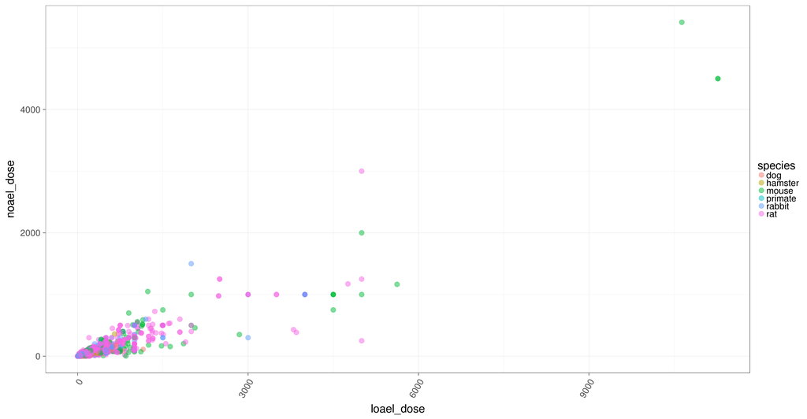

```r
plot_a <- toxcast %>%
ggplot(aes(x = loael_dose, y = noael_dose)) +
  geom_point(aes(color = species), alpha = 1/2, size = 5) +
  theme_bw(base_size = 25) +
  theme(axis.text.x = element_text(angle = 60, hjust = 1))
plot_a
```

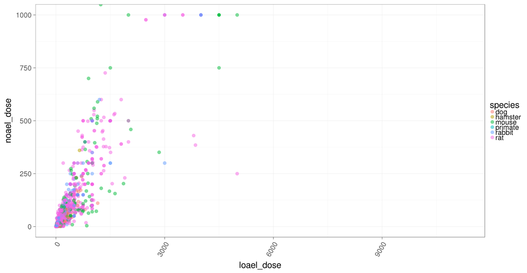

```r
plot_b <- toxcast %>%
ggplot(aes(x = loael_dose, y = noael_dose)) +
  geom_point(aes(color = species), alpha = 1/2, size = 5) +
  coord_cartesian(xlim = c(0, 3000)) +
  coord_cartesian(ylim = c(0, 1000)) +
  theme_bw(base_size = 30) +
  theme(axis.text.x = element_text(angle = 60, hjust = 1))
plot_b
```

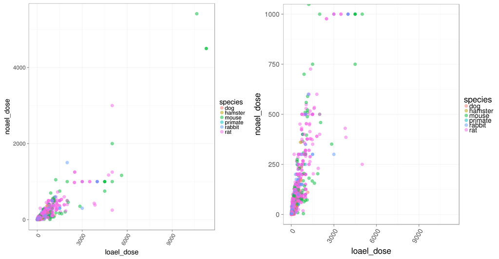

```r
panel <- cowplot::plot_grid(plot_a, plot_b)
panel
```

```r
# the outliers
(outliers <- toxcast %>% select(chemical_name, loael_dose, noael_dose) %>%
  filter(noael_dose > 3000, loael_dose > 4000))
```

```
## # A tibble: 3 × 3
##        chemical_name loael_dose noael_dose
##               <fctr>      <dbl>      <dbl>
## 1 Triethylene glycol      11270       4500
## 2 Triethylene glycol      11270       4500
## 3        Dinotefuran      10635       5414
```

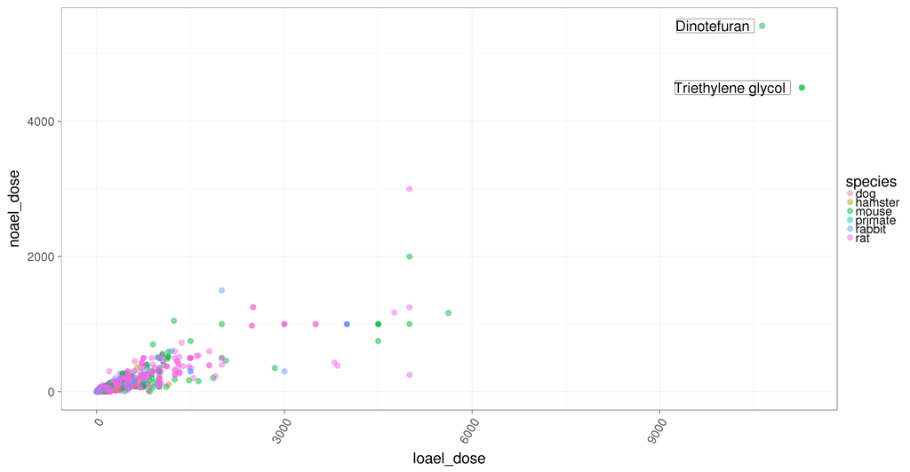

```r
labels <- outliers$chemical_name

# add labels to plot
plot_a <- toxcast %>%
ggplot(aes(x = loael_dose, y = noael_dose)) +
  geom_point(aes(color = species), alpha = 1/2, size = 5) +
  geom_label(data = outliers, aes(x = loael_dose, y = noael_dose, label = labels), hjust = 1.1, size = 10) +
  theme_bw(base_size = 30) +
  theme(axis.text.x = element_text(angle = 60, hjust = 1))
plot_a
```

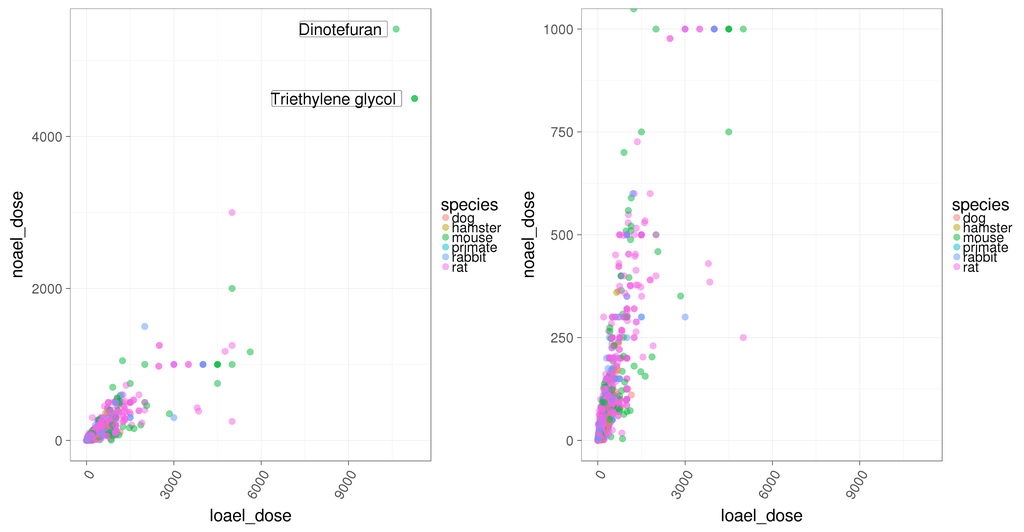

```r
#?geom_label
panel <- cowplot::plot_grid(plot_a, plot_b)
panel
```

## Graph 4) Free choice

Generate a plot of your choosing. It can contain any data from the ToxCast dataset.

You may plot whatever you think is useful to study effects of the chemicals on the animals in the dataset. Be sure to tell a nice story about what can be discovered from your plot.